# Socioeconomical disparities on the usage of checking accounts in Colombia

Duarte Silva

2025-04-23

# Introduction

Financial inclusion is a cornerstone of economic development and social equity. In Colombia, despite significant efforts to expand access to financial services, large disparities remain in the usage of basic financial products, notably **checking accounts**.

Checking accounts (also known as current accounts) are basic financial accounts that allow individuals to deposit money, withdraw funds, and make payments. They are typically used for day-to-day transactions, such as receiving wages, paying bills, and making purchases with a debit card.

This report explores socioeconomical disparities in the usage of checking accounts, leveraging data from DANE (Departamento Administrativo Nacional de Estadística). By analyzing demographic and geographical variables, we aim to identify which populations are less likely to engage with the formal financial system.

Understanding these patterns is crucial for designing targeted interventions, supporting inclusive growth, and ensuring that financial products serve the needs of all Colombians — particularly those in vulnerable or underserved regions.

We use exploratory data analysis and statistical modeling (logistic regression) to highlight regional, gender-based, and age-related disparities, and suggest pathways for actionable policy recommendations.

## Load libraries

```r
library(ggplot2)
library(DT)
library(tidyr)
```

## Load data

```r
dataset_dir <- getwd()

file_path <- file.path(dataset_dir, "DANE_data.csv")

dane_dataset <- read.csv(file_path, header = TRUE, fileEncoding = "UTF-8")
```

# Exploratory Data Analysis (EDA)

### Dataset Overview

```r
dim(dane_dataset)
```

```
## [1] 830743    183
```

```r
table(sapply(dane_dataset, class))
```

```
##
## character   integer   numeric
##       105         3        75
```

### Missing values analysis

```r
na_percentage <- (colSums(is.na(dane_dataset)) / nrow(dane_dataset))* 100

na_categories <- cut(
  na_percentage,
  breaks = c(-Inf, 0, 50, 75, Inf),
  labels = c("0%", ">0% & <=50%", ">50% & <=75%", ">75%"),
  right = TRUE
)

table(na_categories)
```

```
## na_categories
##           0%  >0% & <=50% >50% & <=75%         >75%
##          108           12            7           56
```

- Most variables (108) have no missing values;
- A substantial number (63 variables) have more than 50% missing data.

### Sparsity in Numeric Variables

```r
numeric_dane_dataset <- dane_dataset[sapply(dane_dataset, is.numeric)]

sparsity_check <- data.frame(
  Variable = names(numeric_dane_dataset),
  Zero_Percentage = sapply(numeric_dane_dataset, function(x) mean(x == 0, na.rm = TRUE)* 100)
)

sparsity_check <- sparsity_check[order(-sparsity_check$Zero_Percentage), ]
summary(sparsity_check$Zero_Percentage)
```

```
##    Min. 1st Qu.  Median    Mean 3rd Qu.    Max.
##    0.00    0.00    0.00    3.28    0.00   91.15
```

- Not sparse, minimum coincindes with first quartile and median, revealing that most variables have 0% of variable sparsity;

# Modelling

### Introductory aspects

```r
# Define conversion rate
COP_TO_USD <- 0.000241

#Cleaning
colnames(dane_dataset) <- gsub(" +", " ",
                               gsub("\\.", " ",
                                    gsub("\\.\\.last\\.12\\.months\\.", "(last 12 months)",
                                         gsub("\\.\\.last\\.month\\.", "(last month)",
                                              colnames(dane_dataset)))))


colnames(dane_dataset) <- gsub("([a-zA-Z0-9])\\(last 12 months\\)", "\\1 (last 12 months)", colnames(dane_dataset))
colnames(dane_dataset) <- gsub("([a-zA-Z0-9])\\(last month\\)", "\\1 (last month)", colnames(dane_dataset))


# Columns to convert
monetary_cols <- c(
  'total_labor_income', 'main_job_gross_income', 'overtime_income_amount',
  'food_as_pay_value', 'housing_as_pay_value', 'company_transport_value',
  'other_in_kind_income_value', 'withholding_tax_amount', 'secondary_job_income',
  'Income amount last month', 'Earned income last month',
  'Amount received for rentals (last month)', 'Amount received from pensions or retirement (last month)',
  'Amount received as alimony (last month)', 'Amount received from households in country (last 12 months)',
  'Amount received from households abroad (last 12 months)', 'Amount received from institutions in country (last 12 months)',
  'Amount from national private entities (last 12 months)', 'Amount from government entities (last 12 months)',
  'Amount from More Families in Action (last 12 months)', 'Amount from Youth in Action (last 12 months)',
  'Amount from Colombia Mayor (last 12 months)', 'Amount from other programs (last 12 months)',
  'Amount from entities outside the country (last 12 months)', 'Amount received from investments (last 12 months)',
  'Amount received from severance pay or interest (last 12 months)', 'Amount received from other sources (last 12 months)',
  'Monthly amortization fee', 'Actual monthly rent payment', 'Monthly health payment (COP)',
  'Amount paid in property tax (last 12 months)', 'Amount paid in capital gains tax (last 12 months)',
  'Amount paid in vehicle tax (last 12 months)', 'Amount paid in income and supplementary tax (last 12 months)',
  'Amount paid in taxes on winnings or asset sales (last 12 months)'
)

# Clean & convert columns
for (col in monetary_cols) {
  if (col %in% colnames(dane_dataset)) {
    dane_dataset[[col]] <- suppressWarnings(as.numeric(dane_dataset[[col]]))
    dane_dataset[[col]][dane_dataset[[col]] == 0] <- NA
    dane_dataset[[paste0(col, '_USD')]] <- round(dane_dataset[[col]] ** COP_TO_USD, 3)
  }
}

# Define financial product columns
financial_product_cols <- c(
  'Uses checking account', 'Uses savings account', 'Uses CDT',
  'Uses home purchase loan', 'Uses vehicle purchase loan',
  'Uses free investment loan', 'Uses credit card', 'Uses other financial product'
)

# Binary conversion function
yes_no_to_binary <- function(vec) {
  vec <- tolower(trimws(as.character(vec)))
  return(ifelse(vec == "yes", 1, 0))
}


dane_dataset[financial_product_cols] <- lapply(dane_dataset[financial_product_cols], as.character)


# Apply conversion
dane_dataset[paste0(financial_product_cols, "_bin")] <- lapply(dane_dataset[financial_product_cols], yes_no_to_binary)


# Financial inclusion flags
bin_cols <- paste0(financial_product_cols, '_bin')
dane_dataset$has_any_financial_product <- as.integer(rowSums(dane_dataset[, bin_cols], na.rm = TRUE) > 0)

savings_cols <- paste0(c('Uses checking account', 'Uses savings account', 'Uses CDT'), '_bin')
dane_dataset$uses_savings_product <- rowSums(dane_dataset[, savings_cols], na.rm = TRUE) > 0

credit_cols <- paste0(c('Uses credit card', 'Uses home purchase loan', 'Uses vehicle purchase loan', 'Uses free investment loan'), '_bin')
dane_dataset$uses_credit_product <- rowSums(dane_dataset[, credit_cols], na.rm = TRUE) > 0

# Financial exclusion
dane_dataset$is_financially_excluded <- yes_no_to_binary(dane_dataset[['Uses none of the above']])
```

## Financial Product Usage by Region

### How many data points exist per region? How are they distributed?

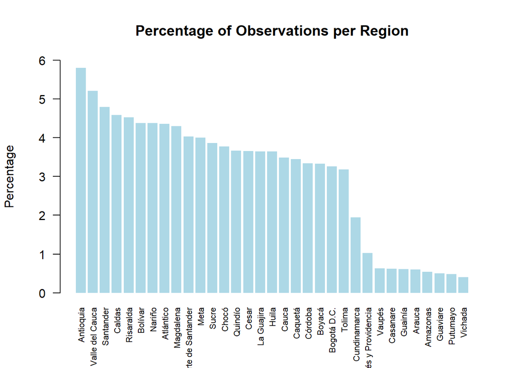

```r
#First, some name cleaning

# Convert 'Region' to factor and then remove the empty string level from the 'Region' factor
dane_dataset$Region = as.factor(dane_dataset$Region)

dane_dataset$Region <- factor(dane_dataset$Region, levels = levels(dane_dataset$Region)[levels(dane_dataset$Region) != ""])

# Drop any unused levels
dane_dataset$Region <- droplevels(dane_dataset$Region)

region_counts <- table(dane_dataset$Region)

region_percentages <- prop.table(region_counts)* 100

region_percentages_sorted <- sort(region_percentages, decreasing = TRUE)

barplot(region_percentages_sorted,
        las = 2,
        col = "lightblue",
        border = NA,
        main = "Percentage of Observations per Region",
        ylab = "Percentage",
        ylim = c(0, 6),
        cex.names = 0.7
)
```

- There’s a lot of dispersion when it comes to data points per region!

**Back to financial usage per region**

```r
# Group by Region and calculate usage proportion of financial products

region_mean_usage <- aggregate(. ~ Region,
                          data = dane_dataset[c("Region", paste0(financial_product_cols, "_bin"))],
                          FUN = mean)


region_mean_usage <- round(region_mean_usage[2:9],3)**100

# Render the region_mean_usage table
datatable(region_mean_usage,
          options = list(
            pageLength = 10,
            scrollX = TRUE,
            dom = 'tip',
            autoWidth = TRUE
          ),
          rownames = FALSE,
          class = 'stripe hover compact'
)
```

| Uses checking account_bin | Uses savings account_bin | Uses CDT_bin | Uses home purchase loan_bin | Uses vehicle purchase loan_bin | Uses free investment loan_bin | Uses credit card_bin | Uses other financial product_bin |
| --- | --- | --- | --- | --- | --- | --- | --- |
| 1.000000000000002e-300 | 1.008001402218733e-71 | 0 | 0 | 0 | 0 | 5.153775207320124e-253 | 0 |
| 1.267650600228232e-270 | 1.346390708501814e-53 | 1.267650600228232e-270 | 1.000000000000002e-200 | 1.606938044258994e-240 | 1.267650600228232e-170 | 6.609557828843834e-144 | 0 |
| 0 | 5.957393428803544e-57 | 0 | 1.000000000000002e-300 | 0 | 1.267650600228232e-270 | 2.03703597633449e-210 | 0 |
| 5.153775207320124e-253 | 3.032370764906632e-74 | 0 | 1.606938044258994e-240 | 1.000000000000002e-300 | 7.888609052210134e-231 | 1.368262370896644e-151 | 2.479335110965961e-189 |
| 6.533186235000723e-223 | 7.188686748713202e-53 | 2.656139888758728e-205 | 1.368914790585882e-157 | 2.656139888758728e-205 | 1.368262370896644e-151 | 3.660323412732312e-101 | 5.153775207320124e-253 |
| 7.888609052210134e-231 | 2.680683429413145e-68 | 0 | 1.267650600228232e-270 | 0 | 7.888609052210134e-231 | 3.142930641582925e-159 | 1.000000000000002e-300 |
| 5.153775207320124e-253 | 2.863455270173849e-57 | 1.606938044258994e-240 | 1.049842551125182e-162 | 5.153775207320124e-253 | 4.268252238120242e-145 | 2.214459024204518e-136 | 8.281797452201473e-193 |
| 1.606938044258994e-240 | 5.174132520423075e-52 | 1.606938044258994e-240 | 7.50516241982518e-173 | 6.533186235000723e-223 | 1.73699988580575e-154 | 6.588745014714443e-126 | 1.267650600228232e-270 |
| 2.582249878086914e-180 | 1.869162738155843e-78 | 0 | 7.888609052210134e-231 | 1.267650600228232e-270 | 5.197603356578064e-156 | 8.281797452201473e-193 | 0 |
| 6.533186235000723e-223 | 2.051408343655442e-60 | 1.267650600228232e-270 | 1.000000000000002e-200 | 6.533186235000723e-223 | 9.51392364630174e-143 | 1.734478615736831e-121 | 0 |

[output cut: 23 more lines]

[figure not shown]

```r
#long format is needed for ggplot2
long_region_usage <- pivot_longer(
  region_mean_usage,
  cols = all_of(paste0(financial_product_cols, "_bin")),
  names_to = "Product",
  values_to = "Proportion"
)


ggplot(long_region_usage, aes(x = Product, y = Proportion)) +
  geom_boxplot(fill = "#69b3a2", color = "black", alpha = 0.8) +
  theme_minimal(base_size = 14) +
  labs(
    title = "Distribution of Financial Product Usage by Region",
    x = "Financial Product",
    y = "Proportion of Users"
  ) +
  theme(
    axis.text.x = element_text(angle = 45, hjust = 1),
    plot.title = element_text(face = "bold", size = 16)
  )
```

### Study of potential preditor variables: Gender, Age, Unemployed, CLASE:

- **Gender**: indicates if the surveyed person is man or a woman;
- **Age**: indicates the surveyed person’s age;
- **Unemployed**: indicates whether the surveyed person is currently unemployed or not;
- **CLASE**: indicates whether the surveyed person lives in an urban or rural setting;

```r
#Convert 'Gender' to factor and then remove the empty string level from the 'Region' factor

dane_dataset$Gender = as.factor(dane_dataset$Gender)

dane_dataset$Gender <- factor(dane_dataset$Gender, levels = levels(dane_dataset$Gender)[levels(dane_dataset$Gender) != ""])

# Drop any unused levels
dane_dataset$Gender <- droplevels(dane_dataset$Gender)

gender_counts = table(dane_dataset$Gender)

round(prop.table(gender_counts)* 100,3)
```

```
##
## Female   Male
##  53.33  46.67
```

- Balanced dataset: 53.33% of datapoints are women and 46.67% are men.

```r
age_counts = table(dane_dataset$Age)

round(prop.table(age_counts)* 100,3)
```

```
##
##     0     1     2     3     4     5     6     7     8     9    10    11    12
## 0.931 1.059 1.158 1.199 1.304 1.312 1.428 1.457 1.512 1.530 1.536 1.550 1.595
##    13    14    15    16    17    18    19    20    21    22    23    24    25
## 1.545 1.601 1.622 1.667 1.645 1.592 1.519 1.541 1.530 1.520 1.611 1.581 1.495
##    26    27    28    29    30    31    32    33    34    35    36    37    38
## 1.485 1.491 1.529 1.526 1.515 1.445 1.456 1.448 1.427 1.413 1.366 1.344 1.357
##    39    40    41    42    43    44    45    46    47    48    49    50    51
## 1.383 1.375 1.341 1.408 1.349 1.361 1.305 1.206 1.172 1.129 1.125 1.137 1.167
##    52    53    54    55    56    57    58    59    60    61    62    63    64
## 1.170 1.184 1.187 1.163 1.137 1.119 1.107 1.105 1.142 1.094 1.067 1.004 0.997
##    65    66    67    68    69    70    71    72    73    74    75    76    77
## 0.928 0.884 0.840 0.790 0.760 0.737 0.646 0.647 0.595 0.585 0.509 0.485 0.423
##    78    79    80    81    82    83    84    85    86    87    88    89    90
## 0.397 0.354 0.336 0.290 0.286 0.263 0.245 0.204 0.180 0.151 0.129 0.117 0.093
##    91    92    93    94    95    96    97    98    99   100   101   102   103
## 0.072 0.061 0.055 0.044 0.036 0.026 0.016 0.012 0.010 0.006 0.004 0.003 0.001
##   104   105   107   108
## 0.000 0.000 0.000 0.000
```

- Pretty dispersed, from 0 to 108 years old!

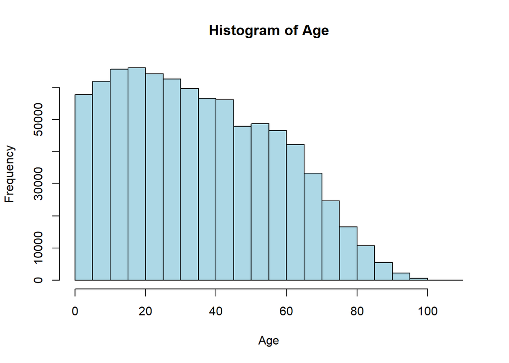

```r
#Testing normality, since it is numeric and the sample size is big enough

# Histogram
hist(dane_dataset$Age, main = "Histogram of Age", xlab = "Age", col = "lightblue", border = "black")
```

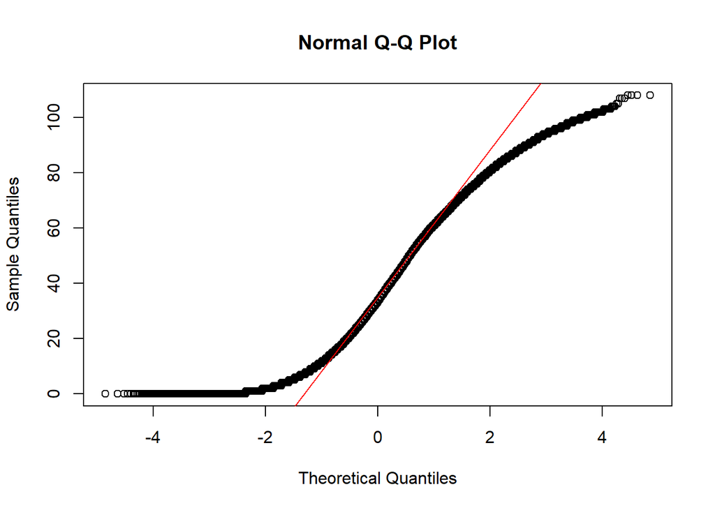

```r
# Q-Q Plot
qqnorm(dane_dataset$Age)
qqline(dane_dataset$Age, col = "red")
```

```r
#Not really normal, it's more sinusoidal than linear the relationship between sample and theoretical normal quantiles.

#The Shapiro normality test only works up until a sample size of 5000

shapiro.test(sample(dane_dataset$Age, 5000))
```

```
##
##  Shapiro-Wilk normality test
##
## data:  sample(dane_dataset$Age, 5000)
## W = 0.96724, p-value < 2.2e-16
```

```r
#The p-value doesn't seem to indicate normality too.

#A categorization can be useful!

dane_dataset$Age_Category <- cut(dane_dataset$Age,
                                 breaks = c(0, 18, 35, 60, 75, Inf),
                                 labels = c("Young", "Young Adult", "Adult", "Older Adult", "Senior"),
                                 right = TRUE)
```

```r
#Convert 'Unemployed' to factor and then replace the empty string level with "Employed"

dane_dataset$Unemployed = as.factor(dane_dataset$Unemployed)

levels(dane_dataset$Unemployed)[levels(dane_dataset$Unemployed) == ""] <- "Employed"

unemployment_counts = table(dane_dataset$Unemployed)

round(prop.table(unemployment_counts)* 100,3)
```

```
##
##   Employed Unemployed
##     94.295      5.705
```

- Very unbalanced, unemployment stands at 5.71%.

```r
dane_dataset$CLASE = as.factor(dane_dataset$CLASE)

##Convert 'CLASE' to factor and then replace  the empty string level from the 'CLASE' factor

dane_dataset$CLASE <- factor(dane_dataset$CLASE, levels = levels(dane_dataset$CLASE)[levels(dane_dataset$CLASE) != ""])

area_counts = table(dane_dataset$CLASE)

round(prop.table(area_counts) * 100,3)
```

```
##
##  Rural  Urban
## 13.133 86.867
```

- Very unbalanced, vast majority of people live in a urban setting (87%).

## Statistical modelling

```r
#Check distribution between interesting variables

vars <- list(
  Region = dane_dataset$Region,
  Gender = dane_dataset$Gender,
  Age_Category = dane_dataset$Age_Category,
  Unemployed = dane_dataset$Unemployed,
  CLASE = dane_dataset$CLASE
)

for (var_name in names(vars)) {
  cat("=====================================\n")
  cat("Contingency Table for:", var_name, "\n")
  cat("=====================================\n")

  var_data <- vars[[var_name]]
  tbl <- table(var_data, dane_dataset$`Uses checking account_bin`)
  prop_tbl <- prop.table(tbl, margin = 1)

  cat("\nAbsolute counts:\n")
  print(tbl)

  cat("\nRow-wise proportions:\n")
  print(round(prop_tbl, 3))

  cat("\n\n")
}
```

```
## =====================================
## Contingency Table for: Region
## =====================================
##
## Absolute counts:
##
## var_data                       0     1
##   Amazonas                  4460     3
##   Antioquia                47998   116
##   Arauca                    4939     0
##   Atlántico                36068   105
##   Bogotá D.C.              26843   167
##   Bolívar                  36134   178
##   Boyacá                   27567    78
##   Caldas                   37927   140
##   Caquetá                  28162   472
##   Casanare                  5106    32
##   Cauca                    28879    57
##   Cesar                    30312    21
##   Chocó                    31289    57
##   Córdoba                  27588   109
##   Cundinamarca             16095    40
##   Guainía                   5024     1
##   Guaviare                  4165     4
##   Huila                    30211    32
##   La Guajira               30248    25
##   Magdalena                35548    96
##   Meta                     33102    62
##   Nariño                   36146   155
##   Norte de Santander       33442    33
##   Putumayo                  3820   136
##   Quindío                  30338    50
##   Risaralda                37354   170
##   San Andrés y Providencia  8475    13
##   Santander                39631   163
##   Sucre                    32034    36
##   Tolima                   26231   159
##   Valle del Cauca          42892   350
##   Vaupés                    5190    73
##   Vichada                   3327     5
```

[output cut: 96 more lines]

```
## =====================================
## Contingency Table for: CLASE
## =====================================
##
## Absolute counts:
##
## var_data      0      1
##    Rural 108851    109
##    Urban 717694   3029
##
## Row-wise proportions:
##
## var_data     0     1
##    Rural 0.999 0.001
##    Urban 0.996 0.004
```

- Throughout all variables, the vast majority indicates absence of checking account usage;
- A more fine-grained approach is needed.

```r
#Logistic regression model with Uses checking account_bin as response variable and Gender, Age, Unemployed & CLASE as predictors

logit_checking_account <- glm(`Uses checking account_bin` ~ Gender + Age + Unemployed + CLASE + Region, data = dane_dataset, family = binomial)

#Testing if the predictors are significant

anova(logit_checking_account, test = "Chisq")
```

```
## Analysis of Deviance Table
##
## Model: binomial, link: logit
##
## Response: Uses checking account_bin
##
## Terms added sequentially (first to last)
##
##
##            Df Deviance Resid. Df Resid. Dev Pr(>Chi)
## NULL                      829682      41268
## Gender      1   159.43    829681      41109  < 2e-16 ***
## Age         1  1302.42    829680      39806  < 2e-16 ***
## Unemployed  1     2.75    829679      39804  0.09723 .
## CLASE       1   373.82    829678      39430  < 2e-16 ***
## Region     32  2168.30    829646      37262  < 2e-16 ***
## ---
## Signif. codes:  0 '***' 0.001 '**' 0.01 '*' 0.05 '.' 0.1 ' ' 1
```

- All variables contribute to explain usage of checking account, except for Unemployed;

📌 **How to interpret the following results?**

The logistic regression model estimates how different factors influence the **probability of having a checking account**. The output presents *odds ratios (OR)*, which tell us how much more (or less) likely someone is to have a checking account depending on their characteristics:

- An **odds ratio greater than 1** means the factor increases the likelihood of having a checking account;
- An **odds ratio less than 1** means the factor decreases that likelihood.

For example, if the odds ratio for “Unemployed = Yes” is 0.6, this means that unemployed individuals are about **40% less likely** to have a checking account compared to employed ones, all else being equal.

**Confidence intervals** indicate the range within which the true odds ratio (OR) for the Colombian population is likely to fall. In statistical inference, the goal is always to draw conclusions about the population based on samples.

```r
#Get OR

exp(coef(logit_checking_account))
```

```
##                    (Intercept)                     GenderMale
##                   3.928773e-05                   1.752910e+00
##                            Age           UnemployedUnemployed
##                   1.029213e+00                   7.625756e-01
##                     CLASEUrban                RegionAntioquia
##                   4.245838e+00                   3.331822e+00
##                   RegionArauca                RegionAtlántico
##                   1.382300e-05                   4.211916e+00
##              RegionBogotá D.C.                  RegionBolívar
##                   8.105333e+00                   7.416329e+00
##                   RegionBoyacá                   RegionCaldas
##                   4.327259e+00                   4.651470e+00
##                  RegionCaquetá                 RegionCasanare
##                   2.732574e+01                   9.799269e+00
##                    RegionCauca                    RegionCesar
##                   2.870914e+00                   1.128178e+00
##                    RegionChocó                  RegionCórdoba
##                   3.249045e+00                   6.250389e+00
##             RegionCundinamarca                  RegionGuainía
##                   4.326305e+00                   3.254704e-01
##                 RegionGuaviare                    RegionHuila
##                   1.411500e+00                   1.565735e+00
##               RegionLa Guajira                RegionMagdalena
##                   1.462101e+00                   4.172803e+00
##                     RegionMeta                   RegionNariño
##                   2.952785e+00                   6.093986e+00
##       RegionNorte de Santander                 RegionPutumayo
##                   1.462321e+00                   5.311094e+01
##                  RegionQuindío                RegionRisaralda
##                   2.076526e+00                   5.991463e+00
## RegionSan Andrés y Providencia                RegionSantander
##                   1.969157e+00                   5.818380e+00
##                    RegionSucre                   RegionTolima
##                   1.646086e+00                   8.578430e+00
##          RegionValle del Cauca                   RegionVaupés
##                   1.127187e+01                   2.100536e+01
##                  RegionVichada
##                   2.509179e+00
```

### Key findings (*ceteris paribus*, that is, with all else constant):

- Men have a 75% higher chance of using a checking account;
- Currently unemployed people have a fraction of the chance (around 70%) of using a checking account when compared to employed ones;
- Every one year age increase, increases 3% the chance of using a checking account;
- Living in a urban region increases circa 4.246 times the chance of using a checking account.

### Do regional results go hand in hand with the current socioeconomic status of Colombia?

```r
#Extract 95% CI for OR

coef_logit <- coef(logit_checking_account)
se_logit <- sqrt(diag(vcov(logit_checking_account)))

# CI (95%)
z_value <- qnorm(0.975)  # 1.96
lower_ci <- coef_logit - z_value * se_logit
upper_ci <- coef_logit + z_value * se_logit

# Convert to OR and respective CI
or <- exp(coef_logit)
lower_or <- exp(lower_ci)
upper_or <- exp(upper_ci)

or_table <- data.frame(
  Lower95CI = round(lower_or,3),
  Upper95CI = round(upper_or,3)
)

print(or_table)
```

```
##                                Lower95CI    Upper95CI
## (Intercept)                        0.000 0.000000e+00
## GenderMale                         1.632 1.883000e+00
## Age                                1.028 1.031000e+00
## UnemployedUnemployed               0.642 9.060000e-01
## CLASEUrban                         3.503 5.146000e+00
## RegionAntioquia                    1.058 1.048900e+01
## RegionArauca                       0.000 1.095319e+72
## RegionAtlántico                    1.336 1.328000e+01
## RegionBogotá D.C.                  2.586 2.540600e+01
## RegionBolívar                      2.368 2.323100e+01
## RegionBoyacá                       1.365 1.372000e+01
## RegionCaldas                       1.481 1.460900e+01
## RegionCaquetá                      8.775 8.509600e+01
## RegionCasanare                     2.998 3.203500e+01
## RegionCauca                        0.898 9.174000e+00
## RegionCesar                        0.336 3.785000e+00
## RegionChocó                        1.017 1.038200e+01
## RegionCórdoba                      1.983 1.969700e+01
## RegionCundinamarca                 1.337 1.399900e+01
## RegionGuainía                      0.034 3.131000e+00
## RegionGuaviare                     0.316 6.313000e+00
## RegionHuila                        0.479 5.117000e+00
## RegionLa Guajira                   0.441 4.846000e+00
## RegionMagdalena                    1.321 1.317600e+01
## RegionMeta                         0.926 9.413000e+00
## RegionNariño                       1.943 1.911700e+01
## RegionNorte de Santander           0.448 4.771000e+00
## RegionPutumayo                    16.894 1.669640e+02
## RegionQuindío                      0.647 6.663000e+00
## RegionRisaralda                    1.912 1.877700e+01
## RegionSan Andrés y Providencia     0.561 6.916000e+00
## RegionSantander                    1.856 1.824200e+01
## RegionSucre                        0.507 5.349000e+00
## RegionTolima                       2.735 2.690500e+01
## RegionValle del Cauca              3.615 3.514500e+01
## RegionVaupés                       6.613 6.671700e+01
## RegionVichada                      0.599 1.051200e+01
```

## Insights on Colombian population

- Men have between 63% and 88% higher odds of having a checking account than women;
- Each additional year of age increases the odds of having a checking account by 2.8% to 3.1%, suggesting a consistent age-related effect;
- Being unemployed decreases the odds by 9% to 36%, suggesting that employment status is a relevant barrier to financial access;
- Living in urban areas is associated with a 3.5 to 5.1 times higher probability of having a checking account.

### Regional Patterns and Interpretation

Why does this happen? A few possible explanations:

- **Sparse data**: If only a handful of individuals from these regions appear in the dataset, especially with little variation in the outcome (e.g., almost all with or without a checking account), the model struggles to estimate a reliable effect;
- **Perfect or quasi-perfect separation**: if, for example, all individuals in a region either have or don’t have a checking account, logistic regression estimates can diverge towards infinity.

### Summary

The model effectively captures national socioeconomic patterns:

- Urbanization and age have clear, interpretable effects;
- Employment remains a relevant factor in financial access;
- Regional disparities in odds ratios largely mirror existing inequalities in infrastructure and development;
- However, care must be taken when interpreting results from underrepresented or low-population regions, where odds ratios can be highly unstable or misleading due to sample issues.

```r
#Pseudo R-squared (McFadden) -> Assessing model's performance

pseudo_r2_mcfadden <- function(model) {
  1 - model$deviance / model$null.deviance
}

pseudo_r2 = pseudo_r2_mcfadden(logit_checking_account)
```

```r
## Using macro-regions

# Initialize a character vector to store macro-regions
Macro_Region <- character(length(dane_dataset$Region))

# Assign macro-region labels based on Region values
Macro_Region[dane_dataset$Region %in% c("Bogotá", "Antioquia", "Boyacá", "Cundinamarca",
                                        "Caldas", "Risaralda", "Quindío", "Santander",
                                        "Norte de Santander", "Tolima", "Huila")] <- "Andean"

Macro_Region[dane_dataset$Region %in% c("Atlántico", "Bolívar", "Magdalena", "La Guajira",
                                        "Sucre", "Córdoba", "Cesar")] <- "Caribbean"

Macro_Region[dane_dataset$Region %in% c("Chocó", "Valle del Cauca", "Cauca", "Nariño")] <- "Pacific"

Macro_Region[dane_dataset$Region %in% c("Amazonas", "Caquetá", "Guainía", "Guaviare", "Meta",
                                        "Putumayo", "Vaupés", "Vichada")] <- "Amazon-Orinoquía"

Macro_Region[dane_dataset$Region %in% c("Arauca", "Casanare")] <- "Eastern Plains"

Macro_Region[dane_dataset$Region %in% c("San Andrés", "Providencia")] <- "Insular"


# Add the new macro-region variable to the data frame
dane_dataset$Macro_Region <- Macro_Region

#New model

logit_checking_account_simplified <- glm(`Uses checking account_bin` ~ Gender + Age + CLASE + Macro_Region,
                        data = dane_dataset, family = binomial)

anova(logit_checking_account_simplified, test = "Chisq")
```

```
## Analysis of Deviance Table
##
## Model: binomial, link: logit
##
## Response: Uses checking account_bin
##
## Terms added sequentially (first to last)
##
##
##              Df Deviance Resid. Df Resid. Dev  Pr(>Chi)
## NULL                        829682      41268
## Gender        1   159.43    829681      41109 < 2.2e-16 ***
## Age           1  1302.42    829680      39806 < 2.2e-16 ***
## CLASE         1   371.33    829679      39435 < 2.2e-16 ***
## Macro_Region  5   651.26    829674      38784 < 2.2e-16 ***
## ---
## Signif. codes:  0 '***' 0.001 '**' 0.01 '*' 0.05 '.' 0.1 ' ' 1
```

```r
pseudo_R2_macro_region <- pseudo_r2_mcfadden(logit_checking_account_simplified)
pseudo_R2_macro_region
```

```
## [1] 0.06020229
```

- The results didn’t change much, even having a decrease on the Pseudo R-squared. It seems that detailed regions are better!
- Region and Urban/rural are usually related. We can explore that a bit more.

```r
# Create contingency table for CLASE and Region by 'Uses checking account'
prop_by_clase_region <- with(dane_dataset,
                             table(CLASE, Region, `Uses checking account_bin`)[,, "1"])

# Convert counts into proportions
total_by_clase_region <- with(dane_dataset,
                              table(CLASE, Region))

prop_by_clase_region <- prop_by_clase_region / total_by_clase_region

prop_by_clase_region_t <- t(prop_by_clase_region)

#Display the proportion table

prop_by_clase_region_t
```

```
##                           CLASE
## Region                            Rural        Urban
##   Amazonas                              0.0006721936
##   Antioquia                0.0006726080 0.0026561055
##   Arauca                                0.0000000000
##   Atlántico                0.0000000000 0.0032682790
##   Bogotá D.C.              0.0000000000 0.0063413708
##   Bolívar                  0.0078908083 0.0044587800
##   Boyacá                   0.0006548788 0.0032518210
##   Caldas                   0.0009986020 0.0040834846
##   Caquetá                  0.0002218279 0.0195225068
##   Casanare                              0.0062281043
##   Cauca                    0.0002131742 0.0023097546
##   Cesar                    0.0004878049 0.0007242786
##   Chocó                    0.0000000000 0.0020952031
##   Córdoba                  0.0014973262 0.0044305447
##   Cundinamarca             0.0013518733 0.0030117733
##   Guainía                               0.0001990050
##   Guaviare                              0.0009594627
##   Huila                    0.0002125850 0.0012138298
##   La Guajira               0.0002171081 0.0009350528
##   Magdalena                0.0007947546 0.0030054556
##   Meta                     0.0003668379 0.0021651270
##   Nariño                   0.0009589567 0.0048251681
##   Norte de Santander       0.0000000000 0.0011260877
##   Putumayo                              0.0343781598
##   Quindío                  0.0020467836 0.0015944823
##   Risaralda                0.0011049724 0.0050001515
##   San Andrés y Providencia              0.0015315740
##   Santander                0.0003830684 0.0046568131
##   Sucre                    0.0000000000 0.0012959896
##   Tolima                   0.0007852375 0.0072783621
##   Valle del Cauca          0.0022039671 0.0088625134
##   Vaupés                                0.0138704161
##   Vichada                               0.0015006002
```

```r
# Interaction between CLASE and Age
logit_checking_account_inter_clase_age <- glm(`Uses checking account_bin` ~ Gender + Age * CLASE + Region,
                                              data = dane_dataset, family = binomial)

# Interaction between Gender and Age
logit_checking_account_inter_gender_age <- glm(`Uses checking account_bin` ~ Gender * Age + CLASE + Region,
                                               data = dane_dataset, family = binomial)

# Interaction between Region and CLASE
logit_checking_account_inter_region_clase <- glm(`Uses checking account_bin` ~ Gender + Age + CLASE * Region,
                                                 data = dane_dataset, family = binomial)
inter_models <- list(
  clase_age = logit_checking_account_inter_clase_age,
  gender_age = logit_checking_account_inter_gender_age,
  region_clase = logit_checking_account_inter_region_clase
)

# Pseudo R²
sapply(inter_models, pseudo_r2_mcfadden)
```

```
##    clase_age   gender_age region_clase
##   0.09683935   0.09783766   0.10048011
```

- Interactions seem to have a positive effect on explaining checking accounts behaviour, especially the interaction between Region and CLASE;
- An interaction between gender and age categories might be useful too. We will use a Chi-square test to assess if gender affects the usage of a checking account across age categories.

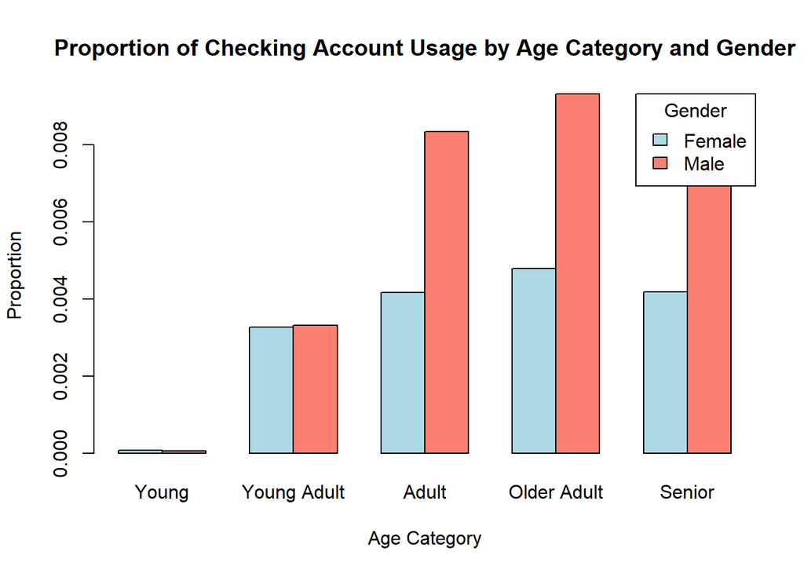

```r
#Setting up and some interesting visualizations

total_by_cat <- table(dane_dataset$Age_Category, dane_dataset$Gender)


users_by_cat <- with(dane_dataset,
                     table(Age_Category, Gender, `Uses checking account_bin`)[,, "1"])

prop_by_cat <- users_by_cat / total_by_cat


# Transpose to compare gender side by side
prop_by_cat_t <- t(prop_by_cat)

# Barplot
barplot(prop_by_cat_t, beside = TRUE, col = c("lightblue", "salmon"),
        legend.text = TRUE, args.legend = list(title = "Gender", x = "topright"),
        main = "Proportion of Checking Account Usage by Age Category and Gender",
        ylab = "Proportion", xlab = "Age Category")
```

```r
# 1. Calculate the number of non-users, except for child
non_users_by_cat <- total_by_cat - users_by_cat

# 2. Setup the Age_Category x Gender x Uses_checking_account (Yes/No) array
full_array <- array(data = c(users_by_cat, non_users_by_cat),
                    dim = c(dim(users_by_cat)[1], dim(users_by_cat)[2], 2),
                    dimnames = list(
                      Age_Category = dimnames(users_by_cat)[[1]],
                      Gender = dimnames(users_by_cat)[[2]],
                      Uses_checking_account = c("Yes", "No")
                    ))

# 3. Chi-square test per age category
for (cat in dimnames(full_array)[["Age_Category"]]) {
  cat_table <- full_array[cat, , ]  # submatrix: [Gender x Yes/No]
  cat("\n== Age category:", cat, "==\n")
  print(chisq.test(cat_table))
}
```

```
##
## == Age category: Young ==
##
##  Pearson's Chi-squared test with Yates' continuity correction
##
## data:  cat_table
## X-squared = 0.0035525, df = 1, p-value = 0.9525
##
##
## == Age category: Young Adult ==
##
##  Pearson's Chi-squared test with Yates' continuity correction
##
## data:  cat_table
## X-squared = 0.026926, df = 1, p-value = 0.8697
##
##
## == Age category: Adult ==
##
##  Pearson's Chi-squared test with Yates' continuity correction
##
## data:  cat_table
## X-squared = 182.34, df = 1, p-value < 2.2e-16
##
##
## == Age category: Older Adult ==
##
##  Pearson's Chi-squared test with Yates' continuity correction
##
## data:  cat_table
## X-squared = 74.636, df = 1, p-value < 2.2e-16
##
##
## == Age category: Senior ==
##
##  Pearson's Chi-squared test with Yates' continuity correction
##
## data:  cat_table
## X-squared = 20.812, df = 1, p-value = 5.068e-06
```

- Among Colombian above 35, the probability of having a checking account is significantly associated with gender.

Let’s try a modelling approach with two interactions: one between Gender and Age_Category, other between Region and CLASE.

```r
# Interaction between Region and CLASE, Gender and Age_Category
logit_checking_account_inter_region_clase_gender_age_category <- glm(`Uses checking account_bin` ~ Gender * Age_Category + CLASE * Region, data = dane_dataset, family = binomial)

pseudo_r2_mcfadden(logit_checking_account_inter_region_clase_gender_age_category)
```

```
## [1] 0.1211795
```

- The best model so far, with 12.1% of explained variability.

# Further Work & Recommendations

This analysis provides a solid foundation for understanding financial inclusion disparities in Colombia. Future work could deepen these insights and enhance policy relevance through the following avenues:

**Analytical Enhancements:**

- **Interaction Effects:** Test interactions between key variables (e.g., *Gender × Region*, *Urban × Region*) to uncover more nuanced forms of exclusion;
- **Machine Learning Models:** Apply tree-based models or ensemble techniques (e.g., Random Forest, XGBoost) to potentially improve predictive performance on large datasets, while addressing interpretability with tools like SHAP;

**Expanded Scope:**

- **Additional Financial Products:** Broaden the analysis to include savings accounts, insurance, or access to credit to capture a fuller picture of financial inclusion;
- **Temporal Dimensions:** Incorporate time-based data, if available, to track the evolution of financial access and evaluate policy impact over time;

**Contextual and Structural Refinements:**

- **Regional Socioeconomic Indicators:** Add contextual variables (e.g., regional GDP, internet coverage) to better explain territorial disparities;
- **Multilevel Modelling:** Consider hierarchical models to account for the nested nature of the data (individuals within regions), offering more precise estimates at different aggregation levels.

# Executive Summary

This analysis sheds light on the patterns of financial inclusion in Colombia, focusing specifically on the use of checking accounts. Using recent DANE microdata, we modeled the probability of having a checking account based on gender, age, employment status, urban/rural classification (CLASE), and region.

**Policy Implications:**

These results point toward the need for:

- Targeted financial literacy and inclusion programs, especially for women and rural populations;
- Regionally differentiated policies that consider the socioeconomic realities of underbanked areas;
- Strengthening digital infrastructure in rural areas to improve access to online banking solutions.

By addressing these disparities, stakeholders can help ensure that the financial system becomes a tool for inclusion rather than a source of further marginalization.